# Exploratory Data Analysis

STOR 320.02 Group 2 (Ex: STOR 320.01 Group 12)

July 28, 2023

# Creator/Deliverier: Dylan Francisco

### Q1: Looking at the Home Health Agency Aggregate report, is there a relationship between the HHRG’s and total payment from Medicare?

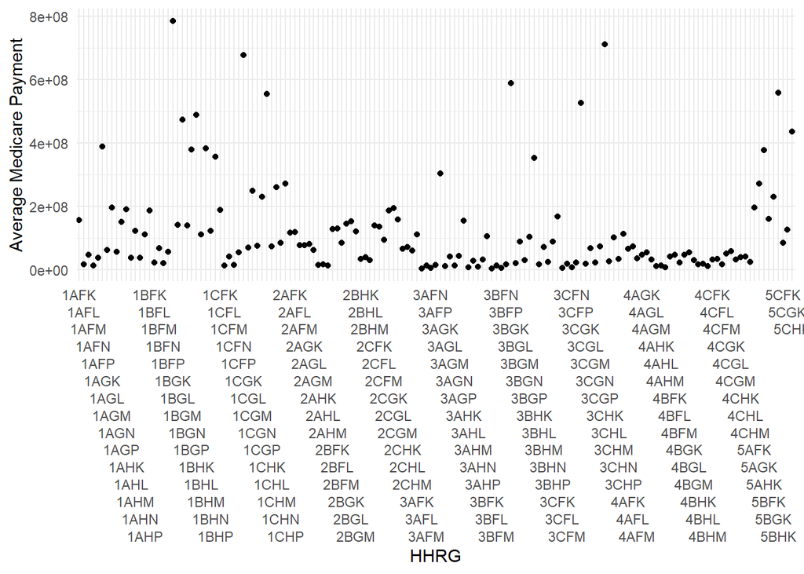

```r
hhadata2015 <- hhadata2015.untidy %>%
  select("HHRG", "Total.Episodes", "Total.HHA.Medicare.Payment.Amount", "Average.HHA.Medicare.Payment.Amount")


ggplot(hhadata2015, aes(x = HHRG, y = Total.HHA.Medicare.Payment.Amount)) +
  geom_point() +
  geom_smooth(method = "lm", se = FALSE) +
  labs(y = "Average Medicare Payment") +
  scale_x_discrete(guide = guide_axis(n.dodge=15)) +
  theme_minimal()
```

### Q2: Is there a relationship between the state’s locations and the total number of episodes relating to an HHRG?

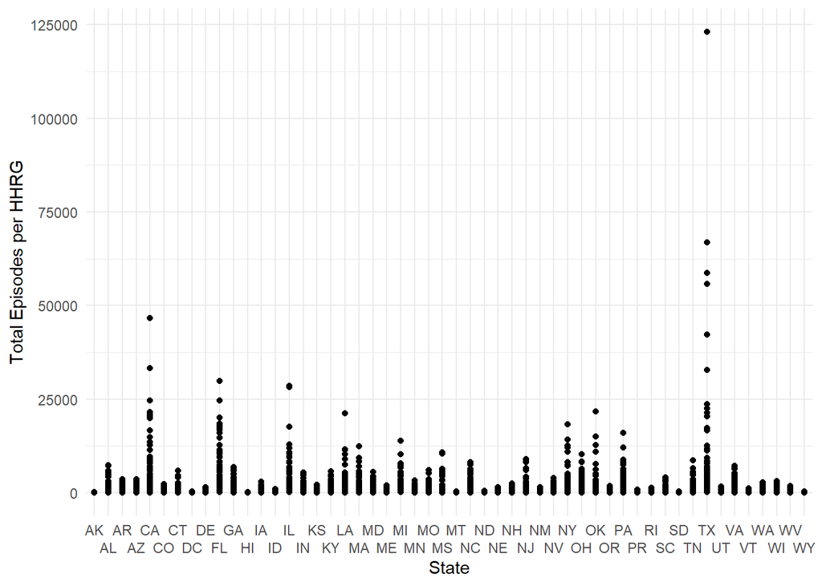

```r
hhaStateData2015 <- hhadatastates2015.untidy %>%
  select("State", "Average.HHA.Charge.Amount", "Total.Episodes" )

ggplot(hhaStateData2015, aes(x = State, y = Total.Episodes)) +
  geom_point() +
  labs(y = "Total Episodes per HHRG") +
  scale_x_discrete(guide = guide_axis(n.dodge=2)) +
  theme_minimal()
```

# Interpreter: Daniela Juarez Gonzalez

### Q1: Is there a relationship between the state of the location of the home agency and the average of the charges that the home health agency submitted for non - LUPA episodes?

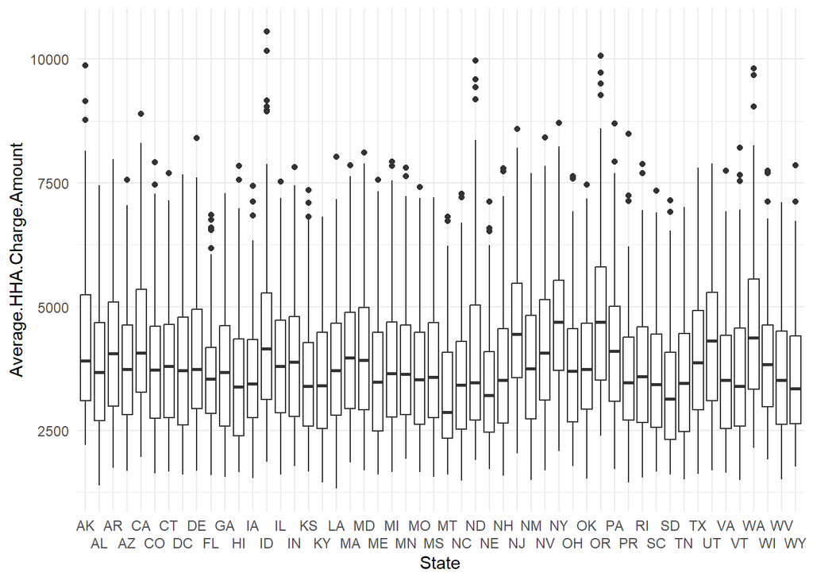

```r
ggplot(hhaStateData2015, aes(x= State, y = Average.HHA.Charge.Amount)) +
  geom_boxplot() +
  scale_x_discrete(guide = guide_axis(n.dodge=2)) +
  theme_minimal()
```

### Q2: How does the HHRG relate to the average amount that medicare paid for non-LUPA episodes adjusted for geographical differences in payment?

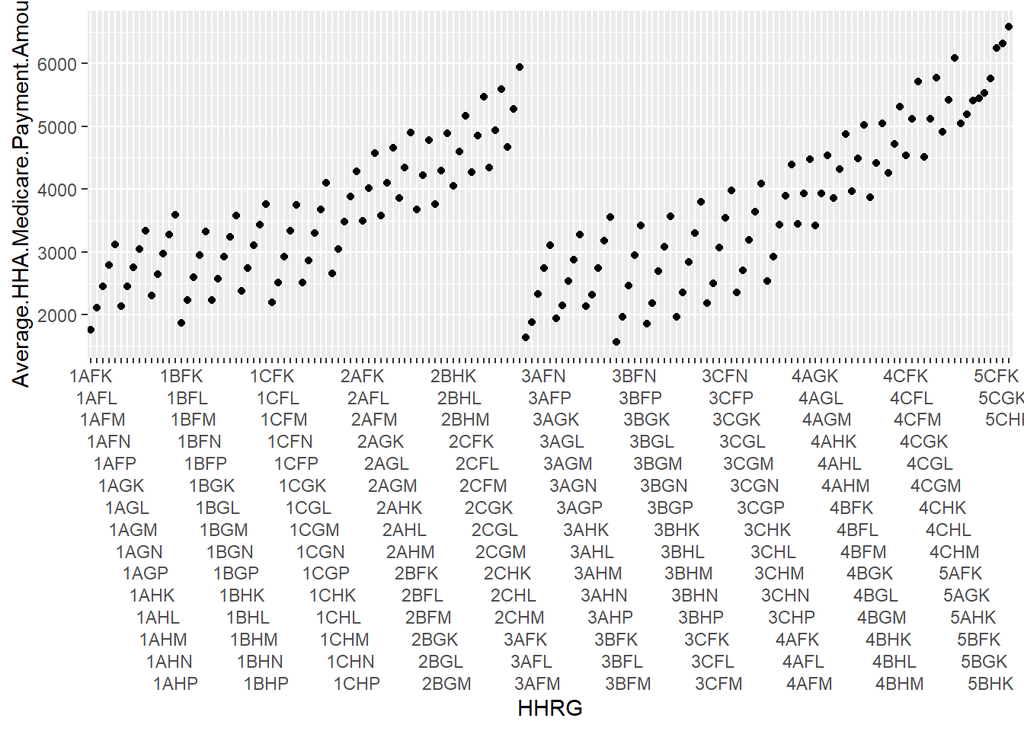

```r
ggplot(hhadata2015, aes(x=HHRG, y = Average.HHA.Medicare.Payment.Amount)) +
  geom_point() +
  scale_x_discrete(guide = guide_axis(n.dodge=15))
```

# Orator: Elvis Atitsoabui

### Q1: Does an increase in the number of beneficiaries with Cancer or Atrial Fibrillation increase the average hha medicare payment amount?

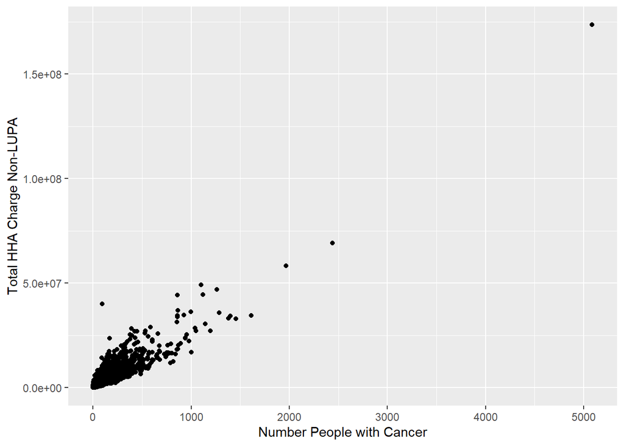

```r
hha_2015 %>% rename( "distinct"="Distinct.Beneficiaries..non.LUPA.") %>% mutate(actual_with_cancer =Percent.of.Beneficiaries.with.Cancer * .01 * distinct) %>%ggplot() + geom_point(aes(x = actual_with_cancer, y=Total.HHA.Charge.Amount..non.LUPA.)) +
  labs(x = "Number People with Cancer", y = "Total HHA Charge Non-LUPA")
```

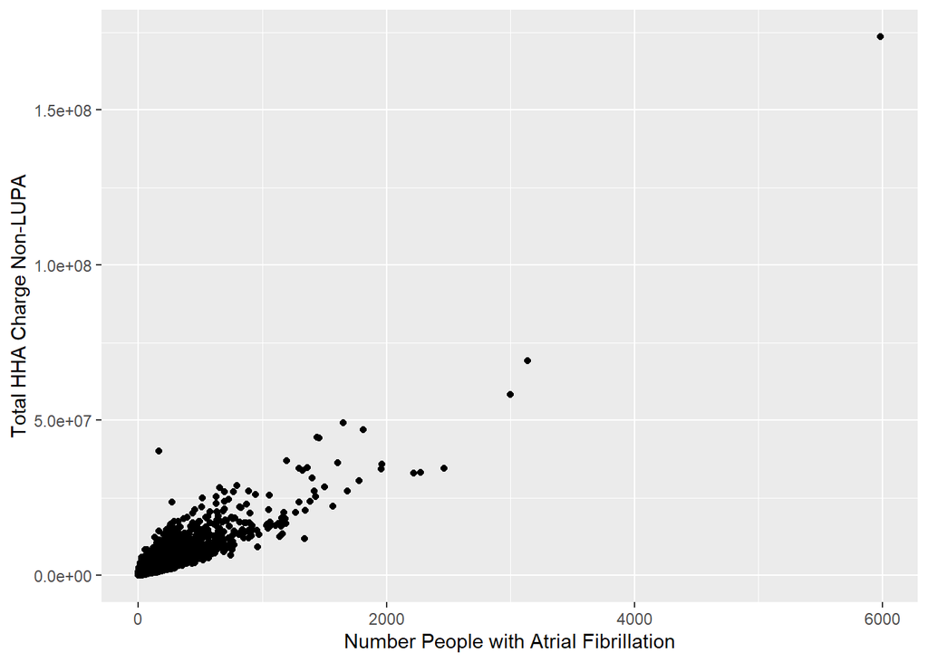

```r
hha_2015 %>% rename( "distinct"="Distinct.Beneficiaries..non.LUPA.") %>% mutate(actual_with_Atrial.Fibrillation =Percent.of.Beneficiaries.with.Atrial.Fibrillation * .01 * distinct) %>%ggplot() + geom_point(aes(x = actual_with_Atrial.Fibrillation, y=Total.HHA.Charge.Amount..non.LUPA.))+
  labs(x = "Number People with Atrial Fibrillation", y = "Total HHA Charge Non-LUPA")
```

### Q2: Using the provider ID dataset, do providers that have more females over males by at least 10 tend to recieve more funding from Medicare?

```r
hhaData2015Females <-  hhadatahhrg2015.untidy %>%
  select("Provider.ID", "Male.Beneficiaries", "Female.Beneficiaries", "Total.HHA.Medicare.Payment.Amount..non.LUPA." ) %>%
  filter(!Male.Beneficiaries>Female.Beneficiaries) %>%
  filter(!Female.Beneficiaries - Male.Beneficiaries < 10) %>%
  transmute(Females = "Females", Average = mean(Total.HHA.Medicare.Payment.Amount..non.LUPA.))


hhaData2015Males <-  hhadatahhrg2015.untidy %>%
  select("Provider.ID", "Male.Beneficiaries", "Female.Beneficiaries", "Total.HHA.Medicare.Payment.Amount..non.LUPA." ) %>%
  filter(Male.Beneficiaries>Female.Beneficiaries) %>%
  filter(!Male.Beneficiaries - Female.Beneficiaries < 10) %>%
  transmute(Males = "Males", Average = mean(Total.HHA.Medicare.Payment.Amount..non.LUPA.))


MalesVFemales <- tibble(
  Sex = c("More Males", "More Females"),
  Average_Paid_By_Medicare = c("$918,996.2", "$2,191,278")


)


MalesVFemaleshtml <- kable(MalesVFemales, format = "html", caption = "Average paid by Medicare for Home Health Agencies based on if more Males or Female Beneficiaries are Present by 10")
MalesVFemaleshtml
```

Average paid by Medicare for Home Health Agencies based on if more Males or Female Beneficiaries are Present by 10

| Sex | Average_Paid_By_Medicare |
| --- | --- |
| More Males | $918,996.2 |
| More Females | $2,191,278 |

# Follow-up Questions

### New Questions Based Off Initial Investigation

- Q1: How does the relationship between HHRG and the total number of episodes help explain the difference between the average payment from medicare?
- Q2: Does a certain HHRG have more prevalence across states or does it differ? What could be the reasoning for certain states to have more of a certain HHRG than others?
- Q3: What is the trend of total cost of HHA for provider across 2013-2015?
- Q4: What is the relationship between the difference in number of males and females at specific provider ID and total HHA medicare payment amount? ### Investigation of Follow-up Questions

### Our group attempted to further investigate Q3 and Q4.

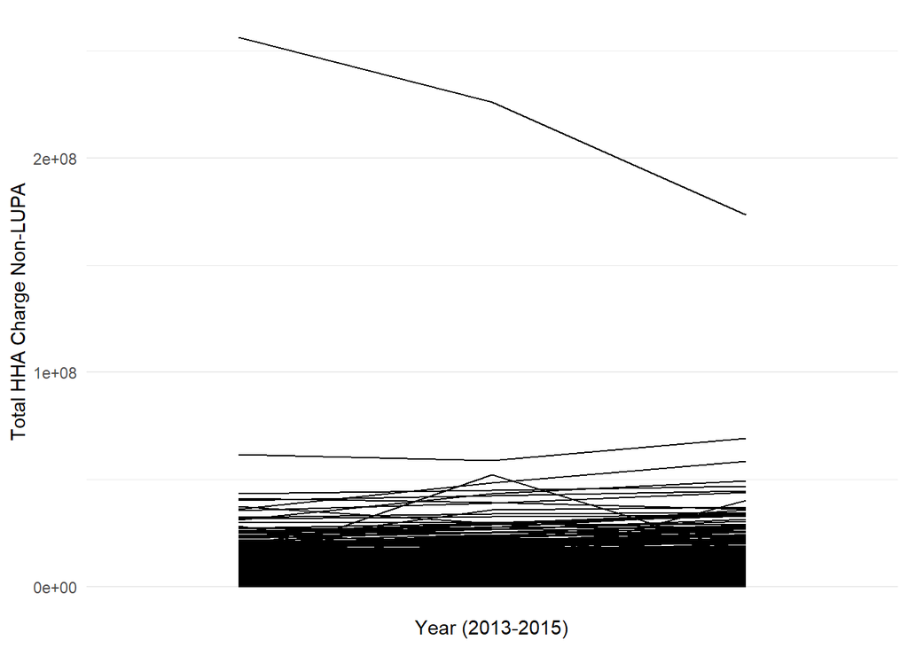

```r
hha_2015_q2 <- hha_2015 %>% select( (1:5), (16:19), 37)

hha_2014_q2 <- hha_2014%>% select( (1:5), (16:19), 37) %>% rename("Total.HHA.Charge.Amount..non.LUPA_2014" = "Total.HHA.Charge.Amount..non.LUPA.") %>% select(Provider.ID, Total.HHA.Charge.Amount..non.LUPA_2014)

hha_2013_q2 <- hha_2013%>% select( (1:5), (16:19), 37) %>% rename("Total.HHA.Charge.Amount..non.LUPA_2013" = "Total.HHA.Charge.Amount..non.LUPA.") %>% select(Provider.ID, Total.HHA.Charge.Amount..non.LUPA_2013)

hha_allyear<- hha_2015_q2 %>% inner_join(hha_2014_q2, "Provider.ID") %>% inner_join(hha_2013_q2, "Provider.ID") %>% select((1:6), (11:12)) %>% rename("2015" = "Total.HHA.Charge.Amount..non.LUPA.", "2014" = "Total.HHA.Charge.Amount..non.LUPA_2014", "2013" = "Total.HHA.Charge.Amount..non.LUPA_2013")

hha_allyear_graph <- hha_allyear %>% gather(`2015`, `2013`, `2014`, key  = Year, value = HHA_charge, convert = TRUE)

ggplot(hha_allyear_graph) + geom_line(aes(x=Year,y=HHA_charge, group = Provider.ID)) + guides(color=F) +
 scale_x_discrete(breaks=c(2013, 2014, 2015),labels=c(2013, 2014, 2015)) + theme_minimal() +
  labs(x = "Year (2013-2015)", y = "Total HHA Charge Non-LUPA")
```

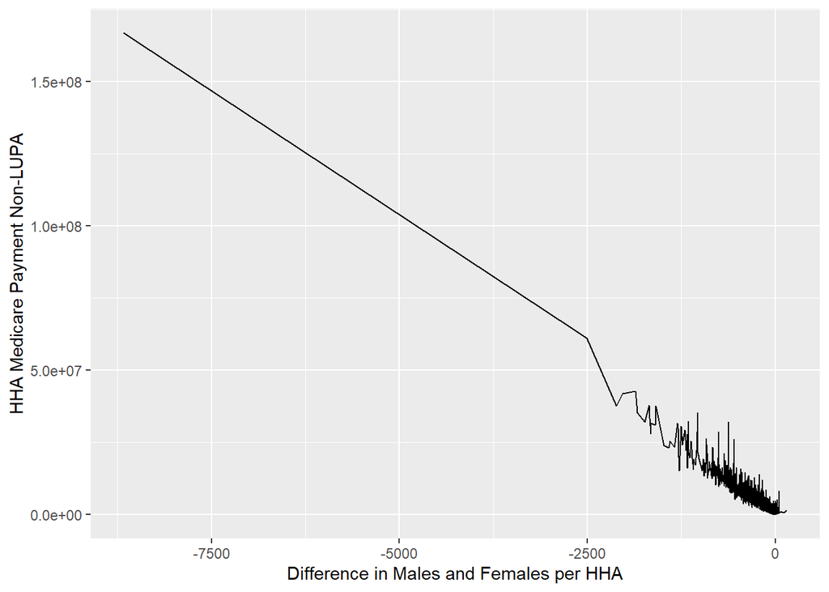

```r
hhaData2015.F2 <- hhadatahhrg2015.untidy %>%
  select("Agency.Name", "Total.HHA.Medicare.Payment.Amount..non.LUPA.", "Female.Beneficiaries", "Male.Beneficiaries") %>%
  mutate(Differnece_In_Males_and_Females = Male.Beneficiaries - Female.Beneficiaries) %>%
  arrange(desc(Differnece_In_Males_and_Females))

ggplot(hhaData2015.F2, aes(x = Differnece_In_Males_and_Females, y = Total.HHA.Medicare.Payment.Amount..non.LUPA.)) +
  geom_line() +
  labs(x = "Difference in Males and Females per HHA", y = "HHA Medicare Payment Non-LUPA")
```

# Summary

We learned a lot from investigating our follow-up questions regarding our datasets. When looking into our first follow-up question, thinking about a plot that would show all of the data we had was a hard question. When thinking about 2-D plots, it was difficult to find one that would fit all of the observations we had. We think this question is interesting because we can show the trend throughout years on how pricing has changed for HHA’s. Our second question was also difficult because of the way the dataset divided the male and female categories. Since the dataset was grouped by the Provider ID, the variables for male beneficiaries and female beneficiaries did not tell us specifically how much of the total charge went to each sex. We thought to use the difference, where a positive number represents that many more males at a HHA and a negative number represents that many more females. We used a line graph to show how the difference in sex at each provider was related to the total medicare payment.

```r
MAE.func=function(actual,predict){
  MAE=mean(abs(actual-predict))
  return(MAE)
}
```

```r
#Seperating the HHRG Description into new variables
hhadata2015.seperated <- hhadata2015.untidy %>%
  separate(col = HHRG.Description, into = c("HHRG.Description", "Therapies", "Clinical_Severity_Level", "Functional_Severity_Level", "Service_Severity_Level"),
           sep = ",", remove = FALSE, extra = "drop")
hhadata2015.seperated$Clinical_Severity_Level <- as.numeric(gsub("\\D", "", hhadata2015.seperated$Clinical_Severity_Level))
hhadata2015.seperated$Functional_Severity_Level <- as.numeric(gsub("\\D", "", hhadata2015.seperated$Functional_Severity_Level))
hhadata2015.seperated$Service_Severity_Level <- as.numeric(gsub("\\D", "", hhadata2015.seperated$Service_Severity_Level))


hhadata2015.seperated <- hhadata2015.seperated %>%
  select("HHRG","HHRG.Description" ,"Therapies", "Clinical_Severity_Level", "Functional_Severity_Level", "Service_Severity_Level", "Total.Episodes", "Average.HHA.Medicare.Payment.Amount", "Total.HHA.Medicare.Payment.Amount")
```

```r
col_names <- c("HHRG","Expected Therapy Visits", "Clinical Severity Level", "Functional Status Level",
               "Service Utilization Level", "Total HHA Medicare Payment Amount" ,"Total Episodes", "Average HHA Medicare Payment Amount")

hhadata2015.seperated_renamed <- hhadata2015.seperated %>%
  select("HHRG", "Therapies", "Clinical_Severity_Level", "Functional_Severity_Level", "Service_Severity_Level", "Total.HHA.Medicare.Payment.Amount" ,"Total.Episodes", "Average.HHA.Medicare.Payment.Amount") %>%
  setNames(col_names) %>%
  slice(1:10)


pretty_kable_table <- kable(hhadata2015.seperated_renamed, format = "html", caption = "HHRG Aggregation Data 2015 (First 10 rows)")




cat(pretty_kable_table, file = "OG Data.html")
```

```r
#creating summaries of the different serverity levels
average_amt_by_service_severity <- hhadata2015.seperated %>%
  group_by(Service_Severity_Level) %>%
  summarize(Average_Amount_Provided_by_Medicare = sum(Total.HHA.Medicare.Payment.Amount) / sum(Distinct.Beneficiaries))
average_amt_by_clincical_severity <- hhadata2015.seperated %>%
  group_by(Clinical_Severity_Level) %>%
  summarize(Average_Amount_Provided_by_Medicare = sum(Total.HHA.Medicare.Payment.Amount) / sum(Distinct.Beneficiaries))
average_amt_by_functional_severity <- hhadata2015.seperated %>%
  group_by(Functional_Severity_Level) %>%
  summarize(Average_Amount_Provided_by_Medicare = sum(Total.HHA.Medicare.Payment.Amount) / sum(Distinct.Beneficiaries))

average_amt_by_clincical_severity
average_amt_by_functional_severity
average_amt_by_service_severity
```

[output not shown]

```r
set.seed(112)

rmse_values_severities <- c()
rmse_values_empty <- c()
rmse_values_service <-  c()
rmse_values_functional <- c()
rmse_values_clinical <- c()
rmse_values_therapies <- c()
rmse_values_therapies_clinical <-  c()
rmse_values_therapies_functional <- c()
rmse_values_therapies_service <- c()
rmse_values_all_var <- c()


#Loop that removes each row, does the lm and predictions for the different models

for (i in 1:nrow(hhadata2015.seperated)) {
  #Model using the 3 different severities
  row_removed <- hhadata2015.seperated[-i, ]

  lm_model_serverties <- lm(Average.HHA.Medicare.Payment.Amount ~ Service_Severity_Level +
                            Functional_Severity_Level + Clinical_Severity_Level,
                            data =  row_removed)
  prediction_severities <- predict(lm_model_serverties, newdata = hhadata2015.seperated[i, ])
  rmse_severities <- ((hhadata2015.seperated$Average.HHA.Medicare.Payment.Amount[i] - prediction_severities)^2)
  rmse_values_severities <- c(rmse_values_severities, rmse_severities)
  hhadata2015.seperated$RMSE_Severities[i] <- rmse_severities
  hhadata2015.seperated$prediction_severities[i] <- prediction_severities


  #Empty model
  lm_model_empty <- lm(Average.HHA.Medicare.Payment.Amount ~ 1, data = row_removed)
  prediction_empty <- predict(lm_model_empty, newdata = hhadata2015.seperated[i, ])
  rmse_empty <-  ((hhadata2015.seperated$Average.HHA.Medicare.Payment.Amount[i] - prediction_empty)^2)
  rmse_values_empty <- c(rmse_values_empty, rmse_empty)
  hhadata2015.seperated$RMSE_Empty[i] <- rmse_empty
  hhadata2015.seperated$prediction_empty[i] <- prediction_empty

  #Model using only Service Severity
  lm_model_service <- lm(Average.HHA.Medicare.Payment.Amount ~ Service_Severity_Level, data = row_removed)
  prediction_service <- predict(lm_model_service, newdata = hhadata2015.seperated[i, ])
  rmse_service <- ((hhadata2015.seperated$Average.HHA.Medicare.Payment.Amount[i] - prediction_service)^2)
  rmse_values_service <- c(rmse_values_service, rmse_service)
  hhadata2015.seperated$RMSE_Service_Severity[i] <- rmse_service
  hhadata2015.seperated$prediction_service[i] <- prediction_service

  #Model using only Functional Severity
  lm_model_functional <- lm(Average.HHA.Medicare.Payment.Amount ~ Functional_Severity_Level, data = row_removed)
  prediction_functional <- predict(lm_model_functional, newdata = hhadata2015.seperated[i, ])
  rmse_functional <- ((hhadata2015.seperated$Average.HHA.Medicare.Payment.Amount[i] - prediction_functional)^2)
  rmse_values_functional <- c(rmse_values_functional, rmse_functional)
  hhadata2015.seperated$RMSE_Functional_Severity[i] <- rmse_functional
  hhadata2015.seperated$prediction_functional[i] <- prediction_functional

  #Model using only Clinical Severity
  lm_model_clinical <- lm(Average.HHA.Medicare.Payment.Amount ~ Clinical_Severity_Level, data = row_removed)
  prediction_clinical <- predict(lm_model_clinical, newdata = hhadata2015.seperated[i, ])
  rmse_clinical <- ((hhadata2015.seperated$Average.HHA.Medicare.Payment.Amount[i] - prediction_clinical)^2)
  rmse_values_clinical <- c(rmse_values_clinical, rmse_clinical)
  hhadata2015.seperated$RMSE_Clinical_Severity[i] <- rmse_clinical
  hhadata2015.seperated$prediction_clinical[i] <- prediction_clinical

  #Model using Therapies
  lm_model_therapies <- lm(Average.HHA.Medicare.Payment.Amount ~ Therapies, data = row_removed)
  prediction_therapies <- predict(lm_model_therapies, newdata = hhadata2015.seperated[i, ])
  rmse_therapies <- ((hhadata2015.seperated$Average.HHA.Medicare.Payment.Amount[i] - prediction_therapies)^2)
  rmse_values_therapies <- c(rmse_values_therapies, rmse_therapies)
  hhadata2015.seperated$RMSE_Therapies[i] <- rmse_therapies
  hhadata2015.seperated$prediction_therapies[i] <- prediction_therapies

  #Model using Therapies + Clinical
  lm_model_therapies_clinical <- lm(Average.HHA.Medicare.Payment.Amount ~ Therapies + Clinical_Severity_Level, data = row_removed)
  prediction_therapies_clinical <- predict(lm_model_therapies_clinical, newdata = hhadata2015.seperated[i, ])
  rmse_therapies_clinical <- ((hhadata2015.seperated$Average.HHA.Medicare.Payment.Amount[i] - prediction_therapies_clinical)^2)
  rmse_values_therapies_clinical <- c(rmse_values_therapies_clinical, rmse_therapies_clinical)
  hhadata2015.seperated$RMSE_Therapies_and_Clinical[i] <- rmse_therapies_clinical
  hhadata2015.seperated$prediction_therapies_and_clinical[i] <- prediction_therapies_clinical

  #Model using Therapies + Functional
  lm_model_therapies_functional <- lm(Average.HHA.Medicare.Payment.Amount ~ Therapies + Functional_Severity_Level, data = row_removed)
  prediction_therapies_functional <- predict(lm_model_therapies_functional, newdata = hhadata2015.seperated[i, ])
  rmse_therapies_functional <- ((hhadata2015.seperated$Average.HHA.Medicare.Payment.Amount[i] - prediction_therapies_functional)^2)
  rmse_values_therapies_functional <- c(rmse_values_therapies_functional, rmse_therapies_functional)
  hhadata2015.seperated$RMSE_Therapies_and_Functional[i] <- rmse_therapies_functional
  hhadata2015.seperated$prediction_therapies_and_functional[i] <- prediction_therapies_functional

  #Model using Therapies + Service
  lm_model_therapies_service <- lm(Average.HHA.Medicare.Payment.Amount ~ Therapies + Service_Severity_Level, data = row_removed)
  prediction_therapies_service <- predict(lm_model_therapies_service, newdata = hhadata2015.seperated[i, ])
  rmse_therapies_service <- ((hhadata2015.seperated$Average.HHA.Medicare.Payment.Amount[i] - prediction_therapies_service)^2)
  rmse_values_therapies_service <- c(rmse_values_therapies_service, rmse_therapies_service)
  hhadata2015.seperated$RMSE_Therapies_and_Service[i] <- rmse_therapies_service
  hhadata2015.seperated$prediction_therapies_and_service[i] <- prediction_therapies_service

  #Model using all variables
  lm_model_all_var <- lm(Average.HHA.Medicare.Payment.Amount ~ Therapies + Service_Severity_Level + Clinical_Severity_Level
                         + Functional_Severity_Level, data = row_removed)
  prediction_all_var <- predict(lm_model_all_var, newdata = hhadata2015.seperated[i, ])
  rmse_all_var <- ((hhadata2015.seperated$Average.HHA.Medicare.Payment.Amount[i] - prediction_all_var)^2)
  rmse_values_all_var <- c(rmse_values_all_var, rmse_all_var)
  hhadata2015.seperated$RMSE_All_Variables[i] <- rmse_all_var
  hhadata2015.seperated$prediction_all_variables[i] <- prediction_all_var
}

average_rmse_severities <- sqrt(mean(rmse_values_severities))
average_rmse_empty <- sqrt(mean(rmse_values_empty))
average_rmse_service <- sqrt(mean(rmse_values_service))
average_rmse_functional <- sqrt(mean(rmse_values_functional))
average_rmse_clinical <- sqrt(mean(rmse_values_clinical))
average_rmse_therapies <- sqrt(mean(rmse_values_therapies))
average_rmse_therapies_clinical <- sqrt(mean(rmse_values_therapies_clinical))
average_rmse_therapies_functional <- sqrt(mean(rmse_values_therapies_functional))
average_rmse_therapies_service <- sqrt(mean(rmse_values_therapies_service))
average_rmse_all_var<- sqrt(mean(rmse_values_all_var))

print(paste("Average Root Mean Squared Error (RMSE) for Empty Model from Cross-Validation:", average_rmse_empty))
```

```
## [1] "Average Root Mean Squared Error (RMSE) for Empty Model from Cross-Validation: 1157.38463464864"
```

```r
print(paste("Average Root Mean Squared Error (RMSE) for Severities Model from Cross-Validation:", average_rmse_severities))
```

```
## [1] "Average Root Mean Squared Error (RMSE) for Severities Model from Cross-Validation: 1119.66809929824"
```

```r
print(paste("Average Root Mean Squared Error (RMSE) for Service Severity Model from Cross-Validation:", average_rmse_service))
```

```
## [1] "Average Root Mean Squared Error (RMSE) for Service Severity Model from Cross-Validation: 1162.95030073788"
```

```r
print(paste("Average Root Mean Squared Error (RMSE) for Functional Severity Model from Cross-Validation:", average_rmse_functional))
```

```
## [1] "Average Root Mean Squared Error (RMSE) for Functional Severity Model from Cross-Validation: 1152.61005661469"
```

```r
print(paste("Average Root Mean Squared Error (RMSE) for Clinical Severity Model from Cross-Validation:", average_rmse_clinical))
```

```
## [1] "Average Root Mean Squared Error (RMSE) for Clinical Severity Model from Cross-Validation: 1120.02749103059"
```

```r
print(paste("Average Root Mean Squared Error (RMSE) for Therapies Model from Cross-Validation:", average_rmse_therapies))
```

```
## [1] "Average Root Mean Squared Error (RMSE) for Therapies Model from Cross-Validation: 653.000397583021"
```

```r
print(paste("Average Root Mean Squared Error (RMSE) for Therapies and Clinical Severity Model from Cross-Validation:", average_rmse_therapies_clinical))
```

```
## [1] "Average Root Mean Squared Error (RMSE) for Therapies and Clinical Severity Model from Cross-Validation: 569.530972943303"
```

```r
print(paste("Average Root Mean Squared Error (RMSE) for Therapies and Functional Severity Model from Cross-Validation:", average_rmse_therapies_functional))
```

```
## [1] "Average Root Mean Squared Error (RMSE) for Therapies and Functional Severity Model from Cross-Validation: 634.027220260747"
```

```r
print(paste("Average Root Mean Squared Error (RMSE) for Therapies and Service Severity Model from Cross-Validation:", average_rmse_therapies_service))
```

```
## [1] "Average Root Mean Squared Error (RMSE) for Therapies and Service Severity Model from Cross-Validation: 416.034766869807"
```

```r
print(paste("Average Root Mean Squared Error (RMSE) for all varibales from Cross-Validation:", average_rmse_all_var))
```

```
## [1] "Average Root Mean Squared Error (RMSE) for all varibales from Cross-Validation: 190.868780817263"
```

```r
scatterplot_all_vars <- ggplot(hhadata2015.seperated, aes(x = Average.HHA.Medicare.Payment.Amount, y = prediction_all_variables)) +
  geom_point() +
  geom_abline(intercept = 0, slope = 1, color = "red", linetype = "dashed") +
  labs(x = "Actual HHA Medicare Payment Amount", y = "Predicted HHA Medicare Payment Amount") +
  ggtitle("Scatterplot with Prediction Line - Therapy Visists and 3 Levels Model") +
  theme_minimal()
ggsave(filename = "scatterplot_all_vars.jpeg", plot = scatterplot_all_vars, width = 7, height = 5, dpi = 300)

scatterplot_severities <- ggplot(hhadata2015.seperated, aes(x = Average.HHA.Medicare.Payment.Amount, y = prediction_severities)) +
  geom_point() +
  geom_abline(intercept = 0, slope = 1, color = "red", linetype = "dashed") +
  labs(x = "Actual HHA Medicare Payment Amount", y = "Predicted HHA Medicare Payment Amount") +
  ggtitle("Scatterplot with Prediction Line - Severities Model") +
  theme_minimal()
```

```r
rmse_data <- tibble(
  Description = c(
    "Empty Model", "Service, Functional, and Clinical Severity Level Model", "Service Utilization Level Model", "Functional Status Level Model",
    "Clinical Severity Level Model", "Therapy Visists Model", "Therapy Visists and Clinical Service Level Model",
    "Therapy Visists and Functional Status Level Model", "Therapy Visists and Service Utilization Level Model", "Therapy Visists and All Three Levels Model"
  ),
  RMSE = round(c(
    average_rmse_empty, average_rmse_severities, average_rmse_service, average_rmse_functional,
    average_rmse_clinical, average_rmse_therapies, average_rmse_therapies_clinical,
    average_rmse_therapies_functional, average_rmse_therapies_service, average_rmse_all_var
  ), 2)
)

rmse_data <- arrange(rmse_data, desc(RMSE))
rmse_data$RMSE <- paste0("$", rmse_data$RMSE)
rmse_kable_table <- kable(rmse_data, format = "html", caption = "RMSE Values For Linear Models", linesep = "<br>", table.attr = 'style="border-collapse: collapse; width: 100%;"',
  row.attr = 'style="border-bottom: 2px solid black;"')
cat(rmse_kable_table, file = "rmse_table.html")
rmse_kable_table
```

RMSE Values For Linear Models

| Description | RMSE |
| --- | --- |
| Service Utilization Level Model | $1162.95 |
| Empty Model | $1157.38 |
| Functional Status Level Model | $1152.61 |
| Clinical Severity Level Model | $1120.03 |
| Service, Functional, and Clinical Severity Level Model | $1119.67 |
| Therapy Visists Model | $653 |
| Therapy Visists and Functional Status Level Model | $634.03 |
| Therapy Visists and Clinical Service Level Model | $569.53 |
| Therapy Visists and Service Utilization Level Model | $416.03 |
| Therapy Visists and All Three Levels Model | $190.87 |

```r
#Creating residual plots for the different types of severity

hhadata2015.seperated$residuals <- hhadata2015.seperated$Average.HHA.Medicare.Payment.Amount - hhadata2015.seperated$Predictions

plot_data1 <- ggplot(hhadata2015.seperated, aes(x = Service_Severity_Level, y = residuals)) +
  geom_point() +
  geom_hline(yintercept = 0, color = "red", linetype = "dashed") +
  labs(x = "Service Severity Level", y = "Residuals") +
  ggtitle("Linear Model Residuals") +
  theme_minimal()

plot_data2 <- ggplot(hhadata2015.seperated, aes(x = Functional_Severity_Level, y = residuals)) +
  geom_point() +
  geom_hline(yintercept = 0, color = "red", linetype = "dashed") +
  labs(x = "Functional Severity Level", y = "Residuals") +
  ggtitle("Linear Model Residuals") +
  theme_minimal()

plot_data3 <- ggplot(hhadata2015.seperated, aes(x = Clinical_Severity_Level, y = residuals)) +
  geom_point() +
  geom_hline(yintercept = 0, color = "red", linetype = "dashed") +
  labs(x = "Clinical Severity Level", y = "Residuals") +
  ggtitle("Linear Model Residuals") +
  theme_minimal()
```

```r
#Combining into one plot
combined_data <- bind_rows(
  data.frame(variable = "Service_Severity_Level", hhadata2015.seperated),
  data.frame(variable = "Functional_Severity_Level", hhadata2015.seperated),
  data.frame(variable = "Clinical_Severity_Level", hhadata2015.seperated)
)

# Create the overlapped plot
ggplot(hhadata2015.seperated, aes(x = as.numeric(Service_Severity_Level), y = residuals, color = "Service_Severity_Level")) +
  geom_point() +
  geom_hline(yintercept = 0, color = "red", linetype = "dashed") +
  labs(x = "Severity Level", y = "Residuals") +
  ggtitle("Linear Model Residuals") +
  scale_x_continuous(breaks = 1:4, labels = c("Severity 1", "Severity 2", "Severity 3", "Severity 4")) +
  theme_minimal() +
  geom_point(data = hhadata2015.seperated, aes(x = as.numeric(Functional_Severity_Level), y = residuals, color = "Functional_Severity_Level")) +
  geom_point(data = hhadata2015.seperated, aes(x = as.numeric(Clinical_Severity_Level), y = residuals, color = "Clinical_Severity_Level")) +
  scale_color_manual(name = "Severity Levels", values = c("Service_Severity_Level" = "blue", "Functional_Severity_Level" = "green", "Clinical_Severity_Level" = "orange"))
```

[output not shown]